# USDA

Cynthia O’Donnell

06/29/2015

# USDA Food Analysis

### Load and View Data

```r
USDA = read.csv('USDA.csv')

str(USDA)
```

```
## 'data.frame':    7058 obs. of  16 variables:
##  $ ID          : int  1001 1002 1003 1004 1005 1006 1007 1008 1009 1010 ...
##  $ Description : Factor w/ 7054 levels "ABALONE,MIXED SPECIES,RAW",..: 1311 1309 1307 2289 2290 2291 2292 2293 2294 2295 ...
##  $ Calories    : int  717 717 876 353 371 334 300 376 403 387 ...
##  $ Protein     : num  0.85 0.85 0.28 21.4 23.24 ...
##  $ TotalFat    : num  81.1 81.1 99.5 28.7 29.7 ...
##  $ Carbohydrate: num  0.06 0.06 0 2.34 2.79 0.45 0.46 3.06 1.28 4.78 ...
##  $ Sodium      : int  714 827 2 1395 560 629 842 690 621 700 ...
##  $ SaturatedFat: num  51.4 50.5 61.9 18.7 18.8 ...
##  $ Cholesterol : int  215 219 256 75 94 100 72 93 105 103 ...
##  $ Sugar       : num  0.06 0.06 0 0.5 0.51 0.45 0.46 NA 0.52 NA ...
##  $ Calcium     : int  24 24 4 528 674 184 388 673 721 643 ...
##  $ Iron        : num  0.02 0.16 0 0.31 0.43 0.5 0.33 0.64 0.68 0.21 ...
##  $ Potassium   : int  24 26 5 256 136 152 187 93 98 95 ...
##  $ VitaminC    : num  0 0 0 0 0 0 0 0 0 0 ...
##  $ VitaminE    : num  2.32 2.32 2.8 0.25 0.26 0.24 0.21 NA 0.29 NA ...
##  $ VitaminD    : num  1.5 1.5 1.8 0.5 0.5 0.5 0.4 NA 0.6 NA ...
```

```r
summary(USDA)
```

```
##        ID
##  Min.   : 1001
##  1st Qu.: 8387
##  Median :13294
##  Mean   :14260
##  3rd Qu.:18337
##  Max.   :93600
##
##                                                        Description
##  BEEF,CHUCK,UNDER BLADE CNTR STEAK,BNLESS,DENVER CUT,LN,0" FA:   2
##  CAMPBELL,CAMPBELL'S SEL MICROWAVEABLE BOWLS,HEA             :   2
##  OIL,INDUSTRIAL,PALM KERNEL (HYDROGENATED),CONFECTION FAT    :   2
##  POPCORN,OIL-POPPED,LOFAT                                    :   2
##  ABALONE,MIXED SPECIES,RAW                                   :   1
##  ABALONE,MXD SP,CKD,FRIED                                    :   1
##  (Other)                                                     :7048
##     Calories        Protein         TotalFat       Carbohydrate
##  Min.   :  0.0   Min.   : 0.00   Min.   :  0.00   Min.   :  0.00
##  1st Qu.: 85.0   1st Qu.: 2.29   1st Qu.:  0.72   1st Qu.:  0.00
##  Median :181.0   Median : 8.20   Median :  4.37   Median :  7.13
##  Mean   :219.7   Mean   :11.71   Mean   : 10.32   Mean   : 20.70
##  3rd Qu.:331.0   3rd Qu.:20.43   3rd Qu.: 12.70   3rd Qu.: 28.17
##  Max.   :902.0   Max.   :88.32   Max.   :100.00   Max.   :100.00
##  NA's   :1       NA's   :1       NA's   :1        NA's   :1
##      Sodium         SaturatedFat     Cholesterol          Sugar
##  Min.   :    0.0   Min.   : 0.000   Min.   :   0.00   Min.   : 0.000
##  1st Qu.:   37.0   1st Qu.: 0.172   1st Qu.:   0.00   1st Qu.: 0.000
##  Median :   79.0   Median : 1.256   Median :   3.00   Median : 1.395
##  Mean   :  322.1   Mean   : 3.452   Mean   :  41.55   Mean   : 8.257
##  3rd Qu.:  386.0   3rd Qu.: 4.028   3rd Qu.:  69.00   3rd Qu.: 7.875
##  Max.   :38758.0   Max.   :95.600   Max.   :3100.00   Max.   :99.800
##  NA's   :84        NA's   :301      NA's   :288       NA's   :1910
##     Calcium             Iron           Potassium          VitaminC
##  Min.   :   0.00   Min.   :  0.000   Min.   :    0.0   Min.   :   0.000
##  1st Qu.:   9.00   1st Qu.:  0.520   1st Qu.:  135.0   1st Qu.:   0.000
##  Median :  19.00   Median :  1.330   Median :  250.0   Median :   0.000
##  Mean   :  73.53   Mean   :  2.828   Mean   :  301.4   Mean   :   9.436
##  3rd Qu.:  56.00   3rd Qu.:  2.620   3rd Qu.:  348.0   3rd Qu.:   3.100
##  Max.   :7364.00   Max.   :123.600   Max.   :16500.0   Max.   :2400.000
##  NA's   :136       NA's   :123       NA's   :409       NA's   :332
##     VitaminE          VitaminD
##  Min.   :  0.000   Min.   :  0.0000
##  1st Qu.:  0.120   1st Qu.:  0.0000
##  Median :  0.270   Median :  0.0000
##  Mean   :  1.488   Mean   :  0.5769
##  3rd Qu.:  0.710   3rd Qu.:  0.1000
##  Max.   :149.400   Max.   :250.0000
##  NA's   :2720      NA's   :2834
```

### Explore Variables

What is the food with the maximum sodium count?

```
## [1] 265
```

How do we find out what food this is?

```r
names(USDA)
```

```
##  [1] "ID"           "Description"  "Calories"     "Protein"
##  [5] "TotalFat"     "Carbohydrate" "Sodium"       "SaturatedFat"
##  [9] "Cholesterol"  "Sugar"        "Calcium"      "Iron"
## [13] "Potassium"    "VitaminC"     "VitaminE"     "VitaminD"
```

```r
USDA$Description[265]
```

```
## [1] SALT,TABLE
## 7054 Levels: ABALONE,MIXED SPECIES,RAW ... ZWIEBACK
```

Oh, it’s Salt. Well, that makes sense.

```r
HighSodium = subset(USDA, Sodium>10000)

nrow(HighSodium)
```

```
## [1] 10
```

There are 10 foods that are high sodium. WHich ones are they?

```r
HighSodium$Description
```

```
##  [1] SALT,TABLE
##  [2] SOUP,BF BROTH OR BOUILLON,PDR,DRY
##  [3] SOUP,BEEF BROTH,CUBED,DRY
##  [4] SOUP,CHICK BROTH OR BOUILLON,DRY
##  [5] SOUP,CHICK BROTH CUBES,DRY
##  [6] GRAVY,AU JUS,DRY
##  [7] ADOBO FRESCO
##  [8] LEAVENING AGENTS,BAKING PDR,DOUBLE-ACTING,NA AL SULFATE
##  [9] LEAVENING AGENTS,BAKING SODA
## [10] DESSERTS,RENNIN,TABLETS,UNSWTND
## 7054 Levels: ABALONE,MIXED SPECIES,RAW ... ZWIEBACK
```

I thought caviar would be high sodium. Let’s figure out where that is.

```r
match("CAVIAR", USDA$Description)
```

```
## [1] 4154
```

```r
USDA$Sodium[4154]
```

```
## [1] 1500
```

Actually, you can do this in one line.

```r
USDA$Sodium[match("CAVIAR", USDA$Description)]
```

```
## [1] 1500
```

### Explore Summary Statistics

```r
summary(USDA$Sodium)
```

```
##    Min. 1st Qu.  Median    Mean 3rd Qu.    Max.    NA's
##     0.0    37.0    79.0   322.1   386.0 38760.0      84
```

```r
sd(USDA$Sodium)
```

```
## [1] NA
```

NA? Let’s fix that!

```r
sd(USDA$Sodium, na.rm=TRUE)
```

```
## [1] 1045.417
```

Now we know that the mean sodium level of all foods in this dataset is 322.1 and the standard deviation is 1045.417. Caviar, with a sodium count of 1500 is above one standard deviation from the mean sodium count.

### Creating Basic Plots

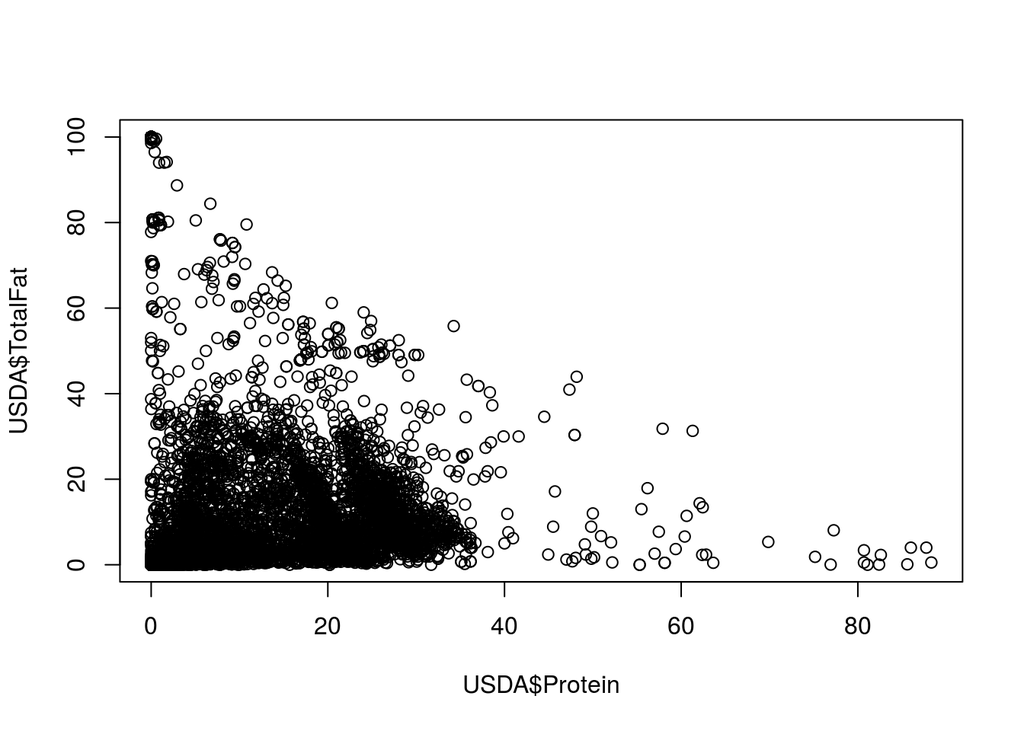

```r
plot(USDA$Protein, USDA$TotalFat)
```

Let’s pretty this up a little bit.

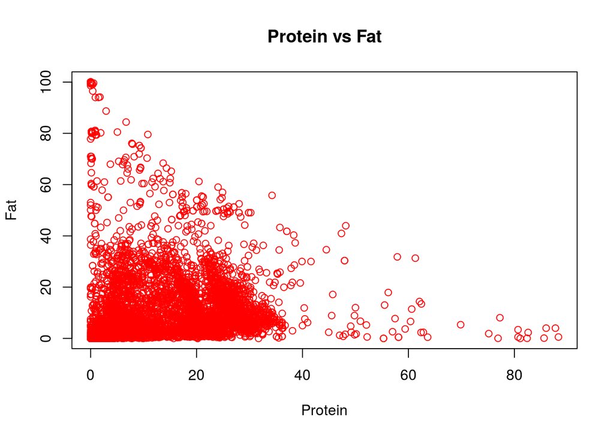

```r
plot(USDA$Protein, USDA$TotalFat, xlab="Protein", ylab="Fat", main="Protein vs Fat", col="red")
```

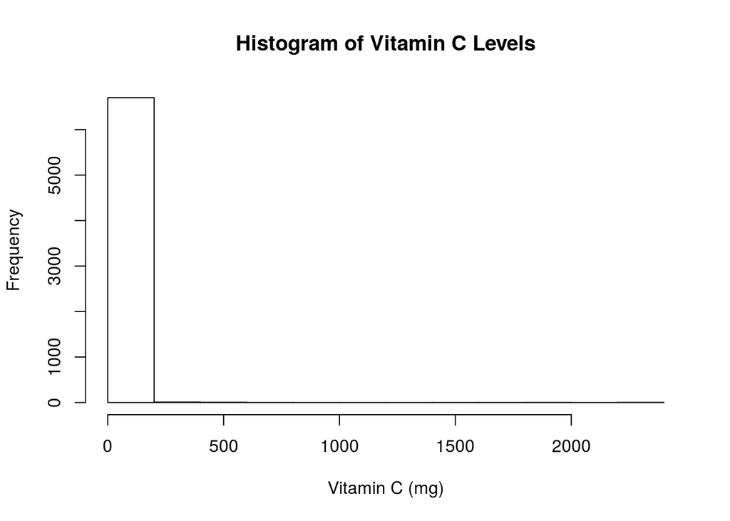

```r
hist(USDA$VitaminC, xlab="Vitamin C (mg)", main="Histogram of Vitamin C Levels")
```

Hm…Let’s change the x-axis, add more breaks and adjust the bin size.

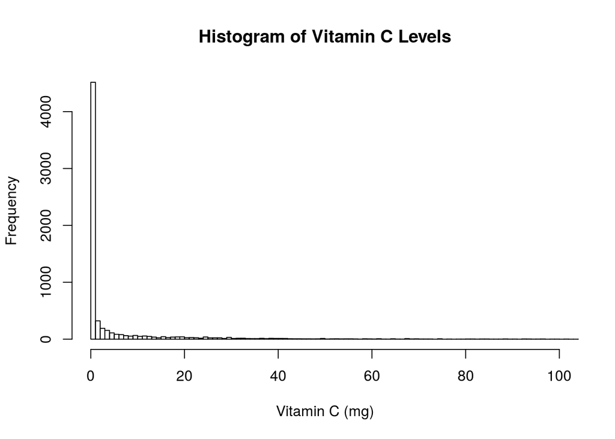

```r
hist(USDA$VitaminC, xlab="Vitamin C (mg)",
     main="Histogram of Vitamin C Levels",
     xlim=(c(0, 100)),
     breaks=2000)
```

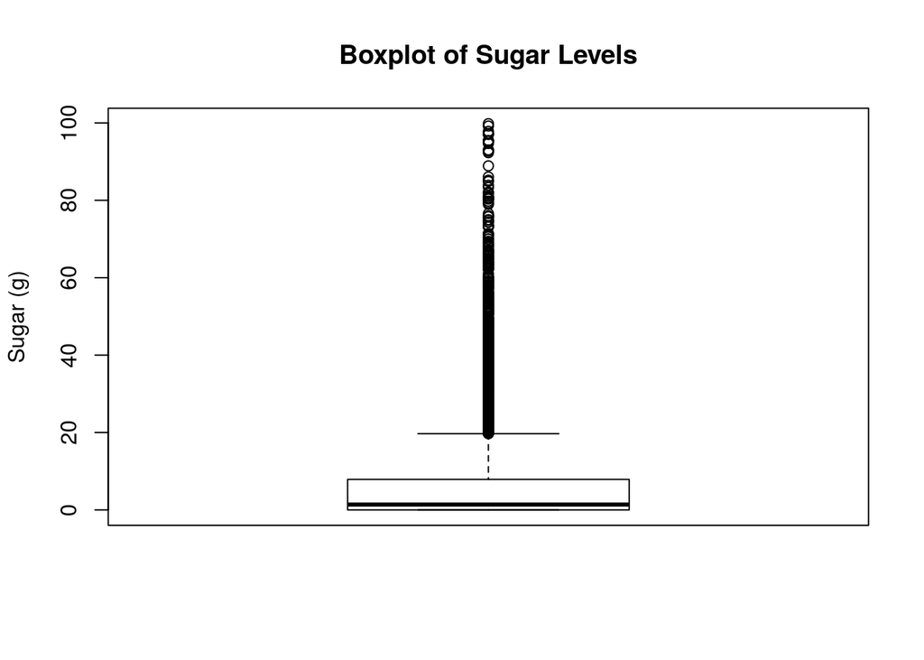

```r
boxplot(USDA$Sugar, main="Boxplot of Sugar Levels", ylab="Sugar (g)")
```

### Adding Variables to a Data Frame

```r
USDA$Sodium[1] > mean(USDA$Sodium, na.rm=TRUE)
```

```
## [1] TRUE
```

```r
USDA$Sodium[50] > mean(USDA$Sodium, na.rm=TRUE)
```

```
## [1] FALSE
```

```r
HighSodium = USDA$Sodium > mean(USDA$Sodium, na.rm=TRUE)
str(HighSodium)
```

```
##  logi [1:7058] TRUE TRUE FALSE TRUE TRUE TRUE ...
```

We can change the data type to numeric instead of logical.

```r
HighSodium = as.numeric(HighSodium)
str(HighSodium)
```

```
##  num [1:7058] 1 1 0 1 1 1 1 1 1 1 ...
```

Now we can add HighSodium to the dataframe.

```r
USDA$HighSodium = HighSodium
```

Let’s add HighFat, High Protein and HighSugar to the dataframe.

```r
USDA$HighProtein = as.numeric(USDA$Protein > mean(USDA$Protein,
                                                  na.rm=TRUE))
USDA$HighFat = as.numeric(USDA$TotalFat > mean(USDA$TotalFat,
                                               na.rm=TRUE))
USDA$HighSugar = as.numeric(USDA$Sugar > mean(USDA$Sugar,
                                              na.rm=TRUE))
```

### Summary Tables

```r
table(USDA$HighSodium)
```

```
##
##    0    1
## 4884 2090
```

This explains that 4884 foods have less sodium that the mean sodium level and 2090 foods have above average sodium levels.

```r
table(USDA$HighSodium, USDA$HighFat)
```

```
##
##        0    1
##   0 3529 1355
##   1 1378  712
```

The rows correspond to the first input High Sodium and the columns correspond to the second input, High Fat.

So we have 3529 low sodium, low fat foods; 1355 low sodium, high fat foods; 1378 low fat, high sodium foods and 712 high sodium, high fat foods.

### Using tapply

```r
tapply(USDA$Iron, USDA$HighProtein, mean, na.rm=TRUE)
```

```
##        0        1
## 2.558945 3.197294
```

Here we group the first parameter by the second parameter and then apply the third parameter to the new grouping.

So we have mean iron counts of 2.55 in low protein foods and 3.197 in high protein foods.

```r
tapply(USDA$VitaminC, USDA$HighSugar, max, na.rm=TRUE)
```

```
##    0    1
## 2400 1900
```

Here we group the Vitamin C variable by whether or not it is high sugar, then we find the max of each group.

```r
tapply(USDA$VitaminC, USDA$HighSugar, summary, na.rm=TRUE)
```

```
## $`0`
##     Min.  1st Qu.   Median     Mean  3rd Qu.     Max.     NA's
##    0.000    0.000    0.000    7.013    1.300 2400.000       94
##
## $`1`
##    Min. 1st Qu.  Median    Mean 3rd Qu.    Max.    NA's
##    0.00    0.00    0.70   16.95   12.00 1900.00      36
```

This shows us the summary of the Vitamin C level of the two groups.